# A reusable Bayesian IRT workflow for instrument validation

### Summary

```r
source(here("scripts", "04_fig4.R"))
```

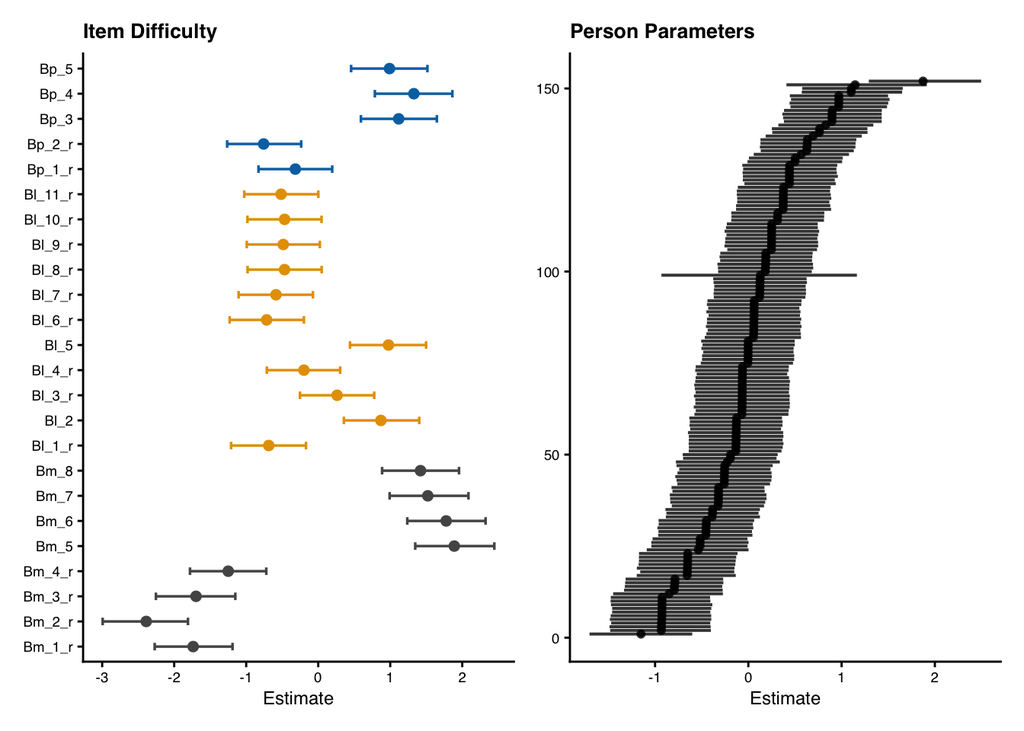

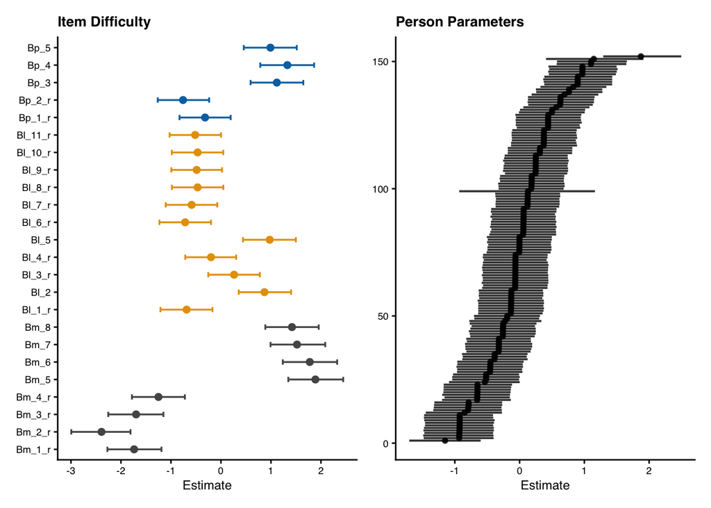

```r
fig_4
```

```r
summary (merge_rsm) # but still, the gaping issue remains.
```

```
##  Family: acat
##   Links: mu = logit; disc = identity
## Formula: response ~ 1 + (1 | item) + (1 | id)
##    Data: data_2 (Number of observations: 3599)
##   Draws: 4 chains, each with iter = 4000; warmup = 2000; thin = 1;
##          total post-warmup draws = 8000
##
## Multilevel Hyperparameters:
## ~id (Number of levels: 152)
##               Estimate Est.Error l-95% CI u-95% CI Rhat Bulk_ESS Tail_ESS
## sd(Intercept)     0.59      0.05     0.51     0.69 1.00     2591     4555
##
## ~item (Number of levels: 24)
##               Estimate Est.Error l-95% CI u-95% CI Rhat Bulk_ESS Tail_ESS
## sd(Intercept)     1.26      0.20     0.94     1.72 1.00      988     2083
##
## Regression Coefficients:
##              Estimate Est.Error l-95% CI u-95% CI Rhat Bulk_ESS Tail_ESS
## Intercept[1]    -0.40      0.25    -0.91     0.10 1.00      588     1140
## Intercept[2]    -0.56      0.25    -1.06    -0.06 1.01      577     1091
## Intercept[3]     2.27      0.26     1.77     2.79 1.01      598     1322
##
## Further Distributional Parameters:
##      Estimate Est.Error l-95% CI u-95% CI Rhat Bulk_ESS Tail_ESS
## disc     1.00      0.00     1.00     1.00   NA       NA       NA
##
## Draws were sampled using sampling(NUTS). For each parameter, Bulk_ESS
## and Tail_ESS are effective sample size measures, and Rhat is the potential
## scale reduction factor on split chains (at convergence, Rhat = 1).
```

# Step 2: Dimensionality — Unidimensional vs Multidimensional

We compare the three competing dimensional structures using the collapsed dataset (`data_2`). All models here use the same 1PL (RSM) specification with the same 4-category response variable, making LOO-CV comparisons valid.

## Fitting the Correlated-Traits model

```r
# Define priors for CT model: Base priors + Correlation prior
priors_ct <- priors_uni + prior(lkj(2), class = "cor")

# Fit CT-MIRT
ct_rsm <- brm(
  formula = bf_ct,
  data = data_2,
  family = brmsfamily("acat", "logit"),
  prior = priors_ct,
  chains = 4,
  cores = 4,
  iter = 4000,
  warmup = 2000,
  seed = 1234,
  # Increase treedepth for complex MIRT
  control = list(adapt_delta = 0.99, max_treedepth = 15),
  file = here("models", "ct_rsm")
)

ct_rsm <- add_criterion(
  ct_rsm,
  criterion = c("loo", "waic")
)

saveRDS(ct_rsm, here("models", "ct_rsm.rds"))
```

## Fitting the Bi-factor Model (BF-MIRT)

```r
bf_rsm <- brm(
  formula = bf_bf,
  data = data_2,
  family = brmsfamily("acat", "logit"),
  prior = priors_uni,
  chains = 4,
  cores = 4,
  iter = 4000,
  warmup = 2000,
  seed = 1234,
  control = list(adapt_delta = 0.99, max_treedepth = 15),
  file = here("models", "bf_rsm")
)

bf_rsm <- add_criterion(
  bf_rsm,
  criterion = c("loo", "waic")
)

saveRDS(bf_rsm, here("models", "bf_rsm.rds"))
```

```r
summary (ct_rsm)
```

```
##  Family: acat
##   Links: mu = logit; disc = identity
## Formula: response ~ 1 + (1 | item) + (0 + dim_m + dim_l + dim_p | id)
##    Data: data_2 (Number of observations: 3599)
##   Draws: 4 chains, each with iter = 4000; warmup = 2000; thin = 1;
##          total post-warmup draws = 8000
##
## Multilevel Hyperparameters:
## ~id (Number of levels: 152)
##                  Estimate Est.Error l-95% CI u-95% CI Rhat Bulk_ESS Tail_ESS
## sd(dim_m)            0.77      0.08     0.61     0.93 1.00     4327     5152
## sd(dim_l)            0.81      0.07     0.69     0.96 1.00     3958     5751
## sd(dim_p)            0.72      0.09     0.55     0.90 1.00     4099     4997
## cor(dim_m,dim_l)     0.36      0.11     0.11     0.56 1.00     1475     2495
## cor(dim_m,dim_p)     0.47      0.12     0.22     0.69 1.00     2827     5135
## cor(dim_l,dim_p)     0.65      0.09     0.45     0.82 1.00     4674     5194
##
## ~item (Number of levels: 24)
##               Estimate Est.Error l-95% CI u-95% CI Rhat Bulk_ESS Tail_ESS
## sd(Intercept)     1.39      0.23     1.03     1.91 1.00     1535     3254
##
## Regression Coefficients:
##              Estimate Est.Error l-95% CI u-95% CI Rhat Bulk_ESS Tail_ESS
## Intercept[1]    -0.54      0.30    -1.11     0.05 1.01     1075     2321
## Intercept[2]    -0.54      0.29    -1.11     0.04 1.01     1036     2266
## Intercept[3]     2.46      0.30     1.89     3.04 1.01     1088     2434
##
## Further Distributional Parameters:
##      Estimate Est.Error l-95% CI u-95% CI Rhat Bulk_ESS Tail_ESS
## disc     1.00      0.00     1.00     1.00   NA       NA       NA
##
## Draws were sampled using sampling(NUTS). For each parameter, Bulk_ESS
## and Tail_ESS are effective sample size measures, and Rhat is the potential
## scale reduction factor on split chains (at convergence, Rhat = 1).
```

```r
summary (bf_rsm)
```

```
##  Family: acat
##   Links: mu = logit; disc = identity
## Formula: response ~ 1 + (1 | item) + (1 | id) + (0 + dim_m || id) + (0 + dim_l || id) + (0 + dim_p || id)
##    Data: data_2 (Number of observations: 3599)
##   Draws: 4 chains, each with iter = 4000; warmup = 2000; thin = 1;
##          total post-warmup draws = 8000
##
## Multilevel Hyperparameters:
## ~id (Number of levels: 152)
##               Estimate Est.Error l-95% CI u-95% CI Rhat Bulk_ESS Tail_ESS
## sd(Intercept)     0.57      0.06     0.46     0.69 1.00     2538     3441
## sd(dim_m)         0.59      0.09     0.41     0.77 1.00     2009     3854
## sd(dim_l)         0.57      0.08     0.43     0.72 1.00     2321     4116
## sd(dim_p)         0.35      0.14     0.05     0.59 1.00      893     1250
##
## ~item (Number of levels: 24)
##               Estimate Est.Error l-95% CI u-95% CI Rhat Bulk_ESS Tail_ESS
## sd(Intercept)     1.39      0.23     1.03     1.92 1.00     1442     2736
##
## Regression Coefficients:
##              Estimate Est.Error l-95% CI u-95% CI Rhat Bulk_ESS Tail_ESS
## Intercept[1]    -0.55      0.28    -1.10     0.01 1.00      839     1770
## Intercept[2]    -0.55      0.28    -1.10     0.01 1.00      828     1781
## Intercept[3]     2.44      0.29     1.88     3.00 1.00      857     1760
##
## Further Distributional Parameters:
##      Estimate Est.Error l-95% CI u-95% CI Rhat Bulk_ESS Tail_ESS
## disc     1.00      0.00     1.00     1.00   NA       NA       NA
##
## Draws were sampled using sampling(NUTS). For each parameter, Bulk_ESS
## and Tail_ESS are effective sample size measures, and Rhat is the potential
## scale reduction factor on split chains (at convergence, Rhat = 1).
```

## Dimensionality comparison

```r
loo_compare(merge_rsm, ct_rsm, bf_rsm, criterion = "loo")
```

```
##           elpd_diff se_diff
## bf_rsm      0.0       0.0
## ct_rsm     -0.2       2.0
## merge_rsm -69.0      13.8
```

```r
# Both CT and BF substantially outperform the unidimensional model,
# confirming that the data have multidimensional structure.
# However, CT and BF are not clearly distinguishable at this stage.
```

# Step 3: Freeing Discrimination Parameters

The RSM constrains all item discriminations to be equal. When items differ substantially in how well they differentiate between respondents, this constraint forces the model to find compromise threshold values, which can produce anomalous threshold ordering. Freeing discrimination parameters (moving from 1PL to 2PL) serves a dual diagnostic purpose: it tests the equal-discrimination assumption and reveals items with poor measurement properties.

## 2PL formula specification

```r
# CT-2pl Formula
bf_ct_2pl <- bf(
  response ~ 1 + (1 | item) + (0 + dim_m + dim_l + dim_p | id),
  disc ~ 1 + (1 | item)
)

priors_ct_2pl <- priors_ct +
  prior("normal(0, 1)", class = "sd", group = "item", dpar = "disc")

# BF-2pl Formula
bf_bf_2pl <- bf(
  response ~ 1 + (1 | item) +
    (1 | id) +
    (0 + dim_m || id) +
    (0 + dim_l || id) +
    (0 + dim_p || id),
  disc ~ 1 + (1 | item)
)

priors_bf_2pl <- priors_uni +
  prior("normal(0, 1)", class = "sd", group = "item", dpar = "disc")
```

## Fit 2pl (ct_grsm, bf_grsm)

```r
ct_grsm <- brm(
  formula = bf_ct_2pl,
  data = data_2,
  family = brmsfamily("acat", "logit"),
  prior = priors_ct_2pl,
  chains = 4,
  cores = 4,
  iter = 4000,
  warmup = 2000,
  seed = 1234,
  control = list(adapt_delta = 0.99, max_treedepth = 15),
  file = here("models", "ct_grsm")
)

ct_grsm <- add_criterion(ct_grsm, criterion = c("loo", "waic"), overwrite = TRUE)
```

```
## Automatically saving the model object in '/Users/chi/Desktop/BIRT_tutorial_belief/models/ct_grsm.rds'
```

```r
saveRDS(ct_grsm, here("models", "ct_grsm.rds"))

bf_grsm <- brm(
  formula = bf_bf_2pl,
  data = data_2,
  family = brmsfamily("acat", "logit"),
  prior = priors_bf_2pl,
  chains = 4,
  cores = 4,
  iter = 4000,
  warmup = 2000,
  seed = 1234,
  control = list(adapt_delta = 0.99, max_treedepth = 15),
  file = here("models", "bf_grsm")
)

bf_grsm <- add_criterion(bf_grsm, criterion = c("loo", "waic"), overwrite = TRUE)
```

```
## Automatically saving the model object in '/Users/chi/Desktop/BIRT_tutorial_belief/models/bf_grsm.rds'
```

```r
saveRDS(bf_grsm, here("models", "bf_grsm.rds"))
```

## Comparing 1PL and 2PL specifications

```r
loo_compare(ct_rsm, bf_rsm, ct_grsm, bf_grsm, criterion = "loo")
```

```
##         elpd_diff se_diff
## ct_grsm    0.0       0.0
## bf_grsm   -0.7       1.4
## bf_rsm  -140.8      22.6
## ct_rsm  -141.0      22.4
```

```r
summary (bf_grsm)
```

```
##  Family: acat
##   Links: mu = logit; disc = log
## Formula: response ~ 1 + (1 | item) + (1 | id) + (0 + dim_m || id) + (0 + dim_l || id) + (0 + dim_p || id)
##          disc ~ 1 + (1 | item)
##    Data: data_2 (Number of observations: 3599)
##   Draws: 4 chains, each with iter = 4000; warmup = 2000; thin = 1;
##          total post-warmup draws = 8000
##
## Multilevel Hyperparameters:
## ~id (Number of levels: 152)
##               Estimate Est.Error l-95% CI u-95% CI Rhat Bulk_ESS Tail_ESS
## sd(Intercept)     1.29      0.42     0.60     2.24 1.00     1785     2107
## sd(dim_m)         2.07      0.67     0.97     3.60 1.00     1869     2347
## sd(dim_l)         1.50      0.50     0.69     2.62 1.00     1916     2410
## sd(dim_p)         1.25      0.45     0.53     2.28 1.00     1768     2447
##
## ~item (Number of levels: 24)
##                    Estimate Est.Error l-95% CI u-95% CI Rhat Bulk_ESS Tail_ESS
## sd(Intercept)          5.11      1.56     2.44     8.46 1.00     2135     2472
## sd(disc_Intercept)     0.79      0.14     0.57     1.10 1.00     2172     3296
##
## Regression Coefficients:
##                Estimate Est.Error l-95% CI u-95% CI Rhat Bulk_ESS Tail_ESS
## Intercept[1]      -0.43      0.93    -2.39     1.32 1.00      831     1739
## Intercept[2]       0.16      0.92    -1.71     1.96 1.00      800     1641
## Intercept[3]       5.95      1.99     2.73    10.35 1.00     1571     2263
## disc_Intercept    -0.81      0.35    -1.45    -0.10 1.00     1688     2540
##
## Draws were sampled using sampling(NUTS). For each parameter, Bulk_ESS
## and Tail_ESS are effective sample size measures, and Rhat is the potential
## scale reduction factor on split chains (at convergence, Rhat = 1).
```

## Wright map: inspecting discrimination and difficulty

```r
source(here("scripts", "05_fig5.R"))
```

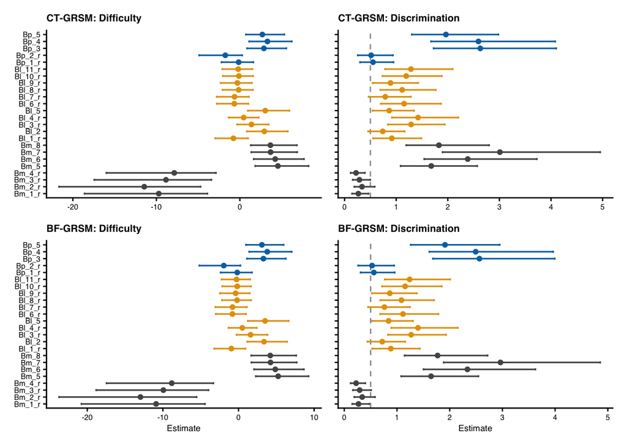

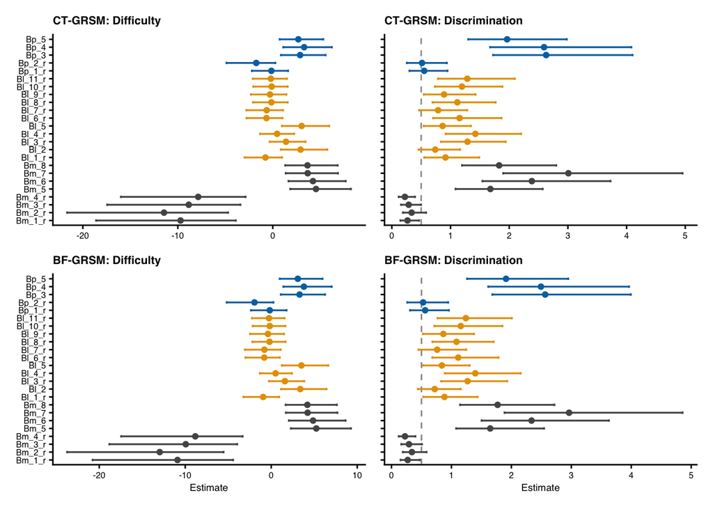

```r
fig_5
```

```r
# The Wright map reveals substantial variation in discrimination
# across items, confirming that the equal-discrimination assumption
# was untenable. Threshold ordering has also improved (see paper
# Table for threshold estimates).
#
# Critically, four items (Bm_1_r to Bm_4_r) stand out with:
# - Discrimination estimates near zero
# - Extremely wide credible intervals on difficulty
# These are candidates for removal.
```

## Cross-check: Bayesian infit/outfit

The decision to flag these items came from freeing the discrimination parameters. As a complementary check, we can also screen items with classical infit/outfit statistics. These have a Bayesian, posterior-predictive form (`easyRaschBayes::infit_statistic`): for each posterior draw it compares the variance-weighted standardised residuals of the observed data against those of model-replicated data, so it is a posterior predictive check rather than a point estimate. We run it on the RSM stage (`merge_rsm`), where infit/outfit are the canonical Rasch-family diagnostic. Misfit is read from the posterior predictive p-value (`ppp < 0.05`) and from the mean-square value (acceptable in `[0.5, 1.5]`).

```r
# install once: remotes::install_github("pgmj/easyRaschBayes")
source(here("scripts", "10_itemfit.R"))
```

```
##     item infit_MNSQ infit_ppp outfit_MNSQ outfit_ppp
##   Bm_2_r      1.651     0.026       1.484      0.120
##   Bm_4_r      1.374     0.002       1.323      0.030
##   Bm_1_r      1.328     0.040       1.279      0.130
##   Bl_6_r      1.093     0.188       1.057      0.298
##   Bm_3_r      1.092     0.308       1.174      0.232
##  Bl_11_r      1.090     0.176       1.083      0.216
##  Bl_10_r      1.082     0.226       1.075      0.276
##   Bl_9_r      1.077     0.214       1.073      0.234
##     Bl_2      1.070     0.282       1.174      0.114
##     Bm_5      1.026     0.398       1.050      0.334
##   Bp_2_r      1.022     0.404       0.999      0.498
##     Bm_8      1.013     0.430       1.059      0.318
##   Bl_7_r      1.003     0.500       1.012      0.458
##   Bl_8_r      0.982     0.552       0.984      0.528
##   Bp_1_r      0.970     0.598       0.984      0.530
##     Bl_5      0.940     0.698       0.992      0.540
##   Bl_3_r      0.939     0.718       0.929      0.736
##     Bm_6      0.886     0.796       0.925      0.708
##     Bp_5      0.883     0.810       0.949      0.624
##     Bm_7      0.820     0.898       0.870      0.816
##   Bl_4_r      0.808     0.978       0.813      0.964
##   Bl_1_r      0.804     0.982       0.817      0.962
##     Bp_4      0.672     0.994       0.741      0.968
##     Bp_3      0.619     1.000       0.645      0.998
```

Infit/outfit independently flag Bm_1_r, Bm_2_r and Bm_4_r. Bm_3_r, by contrast, passes item fit (infit ~1.09) and is only revealed once discrimination is freed. Item-fit and discrimination diagnostics thus have complementary sensitivities; here we proceed with the discrimination-based decision and remove all four, while a reader could reasonably treat Bm_3_r as a borderline case.

# Step 4: Item removal and different link function comparisons

```r
# This provides data3 that is without bm1r~bm4r
data_3 <- readRDS(here("data", "processed", "data_3.rds"))
```

With dimensionality confirmed and problematic items removed, we now compare IRT models defined by different ordinal link functions.

## Fitting the six models

Three link function families are compared, each crossed with two dimensional structures (CT and BF), yielding six models:

```r
# --- GRSM: Generalised Rating Scale Model ---
# Link: adjacent-category logit
# Thresholds: shared across items (only item intercepts vary)
# In brms: family = brmsfamily("acat", "logit")
# Formula:  response ~ 1 + (1 | item) + ...
#
# --- GRM: Graded Response Model ---
# Link: cumulative logit
# Thresholds: item-specific (estimated via cumulative family)
# In brms: family = brmsfamily("cumulative", "logit")
# Formula:  same as GRSM; the family handles the parameterisation
#
# --- GPCM: Generalised Partial Credit Model ---
# Link: adjacent-category logit
# Thresholds: item-specific (via category-specific effects)
# In brms: family = brmsfamily("acat", "logit")
# Formula:  response ~ 1 + (cs(1) | item) + ...
#           cs(1) allows thresholds to vary by item


# --- 1. GRSM  ---

ct_grsm_20 <- brm(
  formula = bf_ct_2pl,
  data = data_3,
  family = brmsfamily("acat", "logit"),
  prior = priors_ct_2pl,
  backend = "cmdstanr",
  save_pars = save_pars(all = TRUE),
  chains = 4, cores = 4, iter = 4000, warmup = 2000, seed = 1234,
  control = list(adapt_delta = 0.99, max_treedepth = 15),
  file = here("models", "ct_grsm_20")
)
ct_grsm_20 <- add_criterion(ct_grsm_20, "loo", overwrite = TRUE)
```

```
## Automatically saving the model object in '/Users/chi/Desktop/BIRT_tutorial_belief/models/ct_grsm_20.rds'
```

```r
saveRDS(ct_grsm_20, here("models", "ct_grsm_20.rds"))

bf_grsm_20 <- brm(
  formula = bf_bf_2pl,
  data = data_3,
  family = brmsfamily("acat", "logit"),
  prior = priors_bf_2pl,
  backend = "cmdstanr",
  save_pars = save_pars(all = TRUE),
  chains = 4, cores = 4, iter = 4000, warmup = 2000, seed = 1234,
  control = list(adapt_delta = 0.99, max_treedepth = 15),
  file = here("models", "bf_grsm_20")
)
bf_grsm_20 <- add_criterion(bf_grsm_20, "loo", overwrite = TRUE)
```

```
## Automatically saving the model object in '/Users/chi/Desktop/BIRT_tutorial_belief/models/bf_grsm_20.rds'
```

```r
saveRDS(bf_grsm_20, here("models", "bf_grsm_20.rds"))


# --- 2. GRM  ---

ct_grm_20 <- brm(
  formula = bf_ct_2pl,
  data = data_3,
  family = brmsfamily("cumulative", "logit"),
  prior = priors_ct_2pl,
  backend = "cmdstanr",
  save_pars = save_pars(all = TRUE),
  chains = 4, cores = 4, iter = 4000, warmup = 2000, seed = 1234,
  control = list(adapt_delta = 0.99, max_treedepth = 15),
  file = here("models", "ct_grm_20")
)
ct_grm_20 <- add_criterion(ct_grm_20, "loo", overwrite = TRUE)
```

```
## Automatically saving the model object in '/Users/chi/Desktop/BIRT_tutorial_belief/models/ct_grm_20.rds'
```

```r
saveRDS(ct_grm_20, here("models", "ct_grm_20.rds"))

bf_grm_20 <- brm(
  formula = bf_bf_2pl,
  data = data_3,
  family = brmsfamily("cumulative", "logit"),
  prior = priors_bf_2pl,
  backend = "cmdstanr",
  save_pars = save_pars(all = TRUE),
  chains = 4, cores = 4, iter = 4000, warmup = 2000, seed = 1234,
  control = list(adapt_delta = 0.99, max_treedepth = 15),
  file = here("models", "bf_grm_20")
)
bf_grm_20 <- add_criterion(bf_grm_20, "loo", overwrite = TRUE)
```

```
## Automatically saving the model object in '/Users/chi/Desktop/BIRT_tutorial_belief/models/bf_grm_20.rds'
```

```r
saveRDS(bf_grm_20, here("models", "bf_grm_20.rds"))

# --- 3. GPCM  ---

bf_ct_gpcm <- bf(
  response ~ 1 + (cs(1) | item) + (0 + dim_m + dim_l + dim_p | id),
  disc ~ 1 + (1 | item)
)

bf_bf_gpcm <- bf(
  response ~ 1 + (cs(1) | item) +
    (1 | id) + (0 + dim_m || id) + (0 + dim_l || id) + (0 + dim_p || id),
  disc ~ 1 + (1 | item)
)

ct_gpcm_20 <- brm(
  formula = bf_ct_gpcm,
  data = data_3,
  family = brmsfamily("acat", "logit"),
  prior = priors_ct_2pl,
  backend = "cmdstanr",
  save_pars = save_pars(all = TRUE),
  chains = 4, cores = 4, iter = 4000, warmup = 2000, seed = 1234,
  control = list(adapt_delta = 0.99, max_treedepth = 15),
  file = here("models", "ct_gpcm_20")
)
ct_gpcm_20 <- add_criterion(ct_gpcm_20, "loo", overwrite = TRUE)
```

```
## Automatically saving the model object in '/Users/chi/Desktop/BIRT_tutorial_belief/models/ct_gpcm_20.rds'
```

```r
saveRDS(ct_gpcm_20, here("models", "ct_gpcm_20.rds"))

bf_gpcm_20 <- brm(
  formula = bf_bf_gpcm,
  data = data_3,
  family = brmsfamily("acat", "logit"),
  prior = priors_bf_2pl,
  backend = "cmdstanr",
  save_pars = save_pars(all = TRUE),
  chains = 4, cores = 4, iter = 4000, warmup = 2000, seed = 1234,
  control = list(adapt_delta = 0.99, max_treedepth = 15),
  file = here("models", "bf_gpcm_20")
)
bf_gpcm_20 <- add_criterion(bf_gpcm_20, "loo", overwrite = TRUE)
```

```
## Automatically saving the model object in '/Users/chi/Desktop/BIRT_tutorial_belief/models/bf_gpcm_20.rds'
```

```r
saveRDS(bf_gpcm_20, here("models", "bf_gpcm_20.rds"))
```

## Inspecting individual LOO diagnostics

Individual LOO summaries reveal Pareto-k diagnostics for each model. High Pareto-k values (> 0.7) indicate observations where the LOO approximation may be unreliable. A model with the best ELPD but many high Pareto-k values should be treated with caution.

```r
loo(ct_grsm_20)
```

```
##
## Computed from 8000 by 2993 log-likelihood matrix.
##
##          Estimate   SE
## elpd_loo  -2855.3 41.0
## p_loo       326.1 10.7
## looic      5710.6 81.9
## ------
## MCSE of elpd_loo is NA.
## MCSE and ESS estimates assume MCMC draws (r_eff in [0.5, 1.8]).
##
## Pareto k diagnostic values:
##                          Count Pct.    Min. ESS
## (-Inf, 0.7]   (good)     2988  99.8%   312
##    (0.7, 1]   (bad)         5   0.2%   <NA>
##    (1, Inf)   (very bad)    0   0.0%   <NA>
## See help('pareto-k-diagnostic') for details.
```

```r
loo(bf_grsm_20)
```

```
##
## Computed from 8000 by 2993 log-likelihood matrix.
##
##          Estimate   SE
## elpd_loo  -2857.6 41.0
## p_loo       327.0 10.7
## looic      5715.3 82.0
## ------
## MCSE of elpd_loo is NA.
## MCSE and ESS estimates assume MCMC draws (r_eff in [0.4, 1.9]).
##
## Pareto k diagnostic values:
##                          Count Pct.    Min. ESS
## (-Inf, 0.7]   (good)     2990  99.9%   265
##    (0.7, 1]   (bad)         3   0.1%   <NA>
##    (1, Inf)   (very bad)    0   0.0%   <NA>
## See help('pareto-k-diagnostic') for details.
```

```r
loo(ct_grm_20)
```

```
##
## Computed from 8000 by 2993 log-likelihood matrix.
##
##          Estimate   SE
## elpd_loo  -2851.2 40.7
## p_loo       342.1 10.4
## looic      5702.3 81.4
## ------
## MCSE of elpd_loo is NA.
## MCSE and ESS estimates assume MCMC draws (r_eff in [0.4, 2.1]).
##
## Pareto k diagnostic values:
##                          Count Pct.    Min. ESS
## (-Inf, 0.7]   (good)     2991  99.9%   385
##    (0.7, 1]   (bad)         2   0.1%   <NA>
##    (1, Inf)   (very bad)    0   0.0%   <NA>
## See help('pareto-k-diagnostic') for details.
```

```r
loo(bf_grm_20)
```

```
##
## Computed from 8000 by 2993 log-likelihood matrix.
##
##          Estimate   SE
## elpd_loo  -2849.4 40.7
## p_loo       339.3 10.3
## looic      5698.7 81.4
## ------
## MCSE of elpd_loo is NA.
## MCSE and ESS estimates assume MCMC draws (r_eff in [0.5, 1.9]).
##
## Pareto k diagnostic values:
##                          Count Pct.    Min. ESS
## (-Inf, 0.7]   (good)     2992  100.0%  394
##    (0.7, 1]   (bad)         1    0.0%  <NA>
##    (1, Inf)   (very bad)    0    0.0%  <NA>
## See help('pareto-k-diagnostic') for details.
```

```r
loo(ct_gpcm_20)
```

```
##
## Computed from 8000 by 2993 log-likelihood matrix.
##
##          Estimate   SE
## elpd_loo  -2821.3 41.8
## p_loo       364.4 12.1
## looic      5642.6 83.6
## ------
## MCSE of elpd_loo is NA.
## MCSE and ESS estimates assume MCMC draws (r_eff in [0.3, 1.8]).
##
## Pareto k diagnostic values:
##                          Count Pct.    Min. ESS
## (-Inf, 0.7]   (good)     2984  99.7%   118
##    (0.7, 1]   (bad)         9   0.3%   <NA>
##    (1, Inf)   (very bad)    0   0.0%   <NA>
## See help('pareto-k-diagnostic') for details.
```

```r
loo(bf_gpcm_20)
```

```
##
## Computed from 8000 by 2993 log-likelihood matrix.
##
##          Estimate   SE
## elpd_loo  -2836.5 41.9
## p_loo       361.4 11.8
## looic      5673.1 83.8
## ------
## MCSE of elpd_loo is NA.
## MCSE and ESS estimates assume MCMC draws (r_eff in [0.2, 1.9]).
##
## Pareto k diagnostic values:
##                          Count Pct.    Min. ESS
## (-Inf, 0.7]   (good)     2986  99.8%   48
##    (0.7, 1]   (bad)         7   0.2%   <NA>
##    (1, Inf)   (very bad)    0   0.0%   <NA>
## See help('pareto-k-diagnostic') for details.
```

```r
loo_compare(
  ct_grsm_20, bf_grsm_20,
  ct_grm_20,  bf_grm_20,
  ct_gpcm_20, bf_gpcm_20
)
```

```
##            elpd_diff se_diff
## ct_gpcm_20   0.0       0.0
## bf_gpcm_20 -15.2       5.3
## bf_grm_20  -28.1      10.1
## ct_grm_20  -29.9       9.9
## ct_grsm_20 -34.0       8.8
## bf_grsm_20 -36.3       8.9
```

```r
# Stacking weights across all six models
model_weights(
  ct_grsm_20, bf_grsm_20,
  ct_grm_20,  bf_grm_20,
  ct_gpcm_20, bf_gpcm_20
)
```

```
##   ct_grsm_20   bf_grsm_20    ct_grm_20    bf_grm_20   ct_gpcm_20   bf_gpcm_20
## 3.683987e-05 2.570583e-06 6.594964e-06 2.396761e-01 7.601135e-01 1.643497e-04
```

## Clean loo

Moment matching and exact `reloo` refits are computationally expensive (each refit re-runs the full sampler, ~30 min). The code that produced the calibrated LOO objects is shown below; we then load the saved results.

```r
# CT-GRM: moment matching + exact reloo for the few high-Pareto-k points
loo_ct_grm_20 <- loo(ct_grm_20, moment_match = TRUE, reloo = TRUE)
saveRDS(loo_ct_grm_20, here("models", "loo", "loo_ct_grm_20.rds"))

# BF-GRM: moment matching
loo_bf_grm_20 <- loo(bf_grm_20, moment_match = TRUE)
saveRDS(loo_bf_grm_20, here("models", "loo", "loo_bf_grm_20.rds"))
```

```r
loo_ct_grm_20 <- readRDS(here("models", "loo", "loo_ct_grm_20.rds"))
loo_bf_grm_20 <- readRDS(here("models", "loo", "loo_bf_grm_20.rds"))
```

## Clean compare

```r
loo_compare(loo_bf_grm_20, loo_ct_grm_20)
```

```
##           elpd_diff se_diff
## bf_grm_20  0.0       0.0
## ct_grm_20 -1.7       1.2
```

```r
loo_model_weights(list(bf_grm = loo_bf_grm_20, ct_grm = loo_ct_grm_20))
```

```
## Method: stacking
## ------
##        weight
## bf_grm 1.000
## ct_grm 0.000
```

# Step 5: Final model Wright map

```r
source(here("scripts", "07_fig6.R"))
```

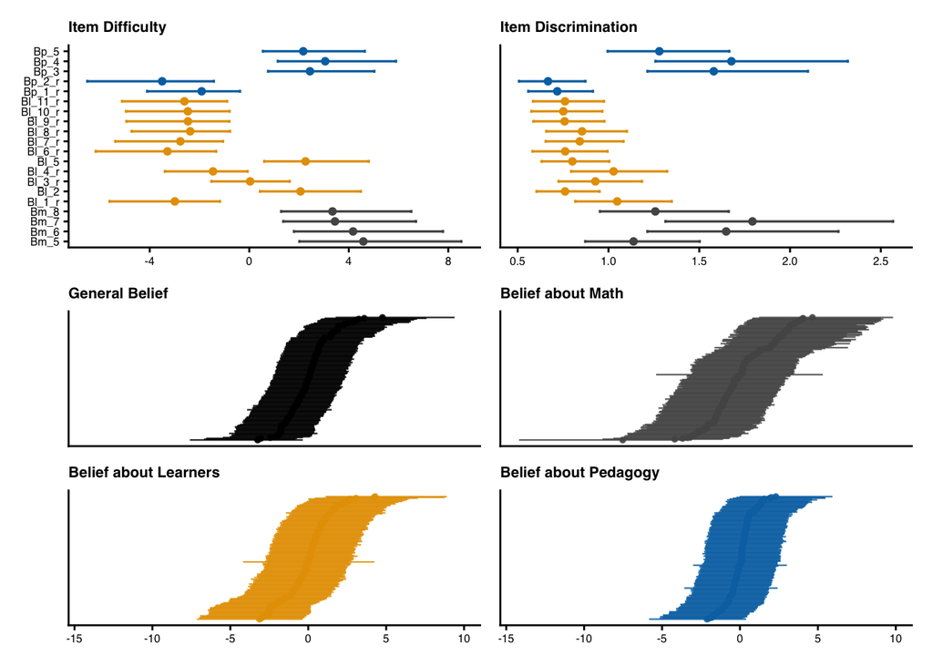

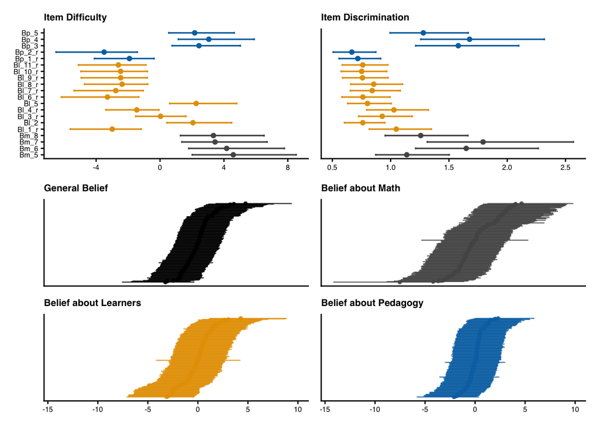

```r
fig_6
```

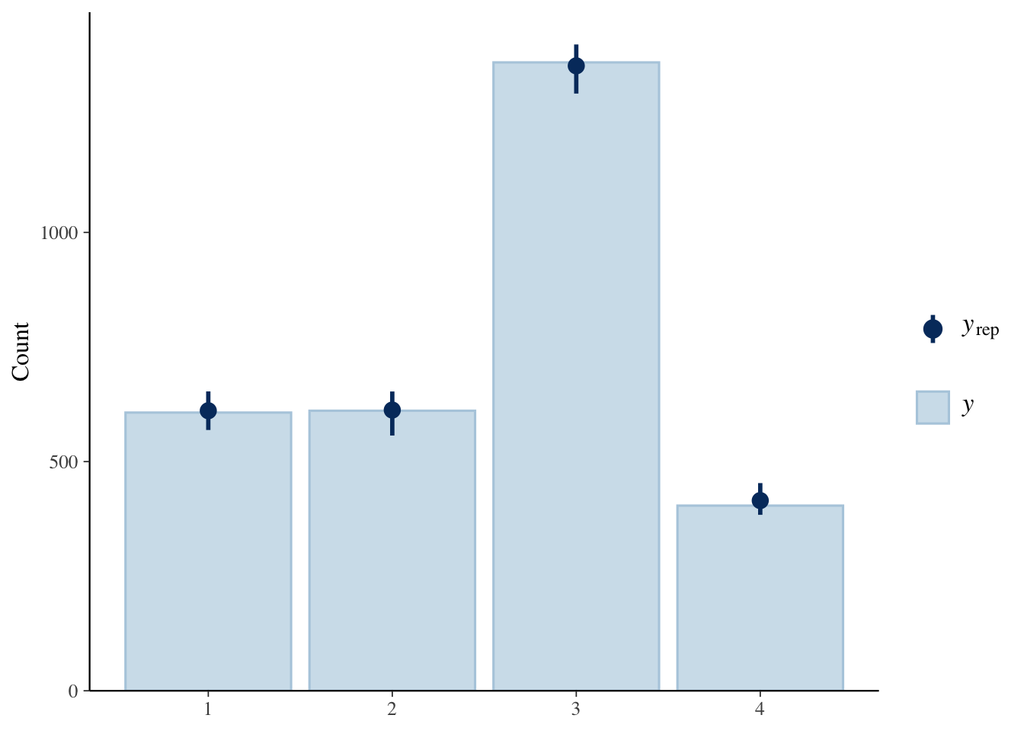

```r
pp_check(bf_grm_20,type = "bars", ndraws = 100)
```

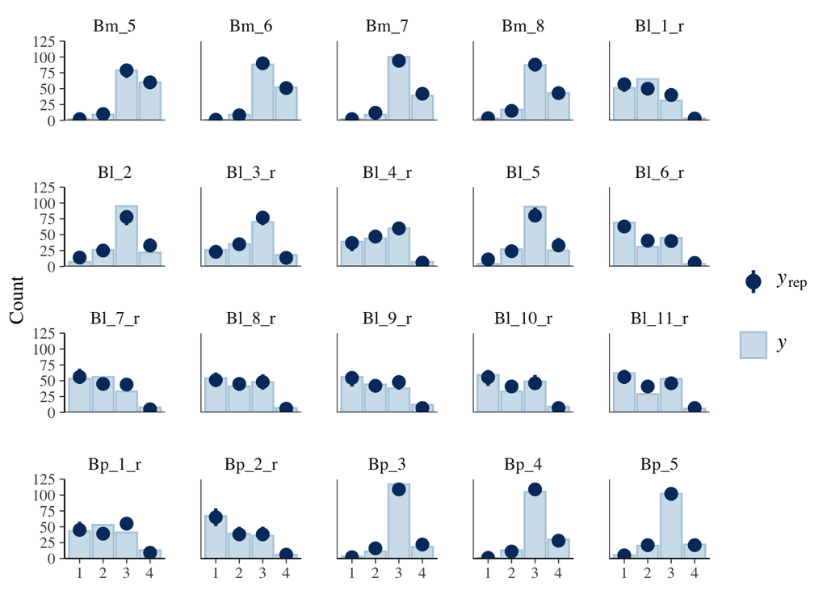

```r
pp_check(bf_grm_20, type = "bars_grouped", group = "item", ndraws = 100)
```

## Reliability of the final model

Finally, we check the reliability of the final model with two complementary coefficients. Because the instrument is bi-factor, no single latent dimension is meant to carry the measurement on its own, so we report (i) the model-based omega coefficients (`omega_total`, the reliability of the total score, with `omega_H` and `ECV` describing the dominant general factor), computed per posterior draw, and (ii) the per-dimension person reliability (empirical/EAP and the Bayesian RMU of Bignardi, Kievit & Bürkner, 2025). The two views answer different questions: the EAP/RMU figures (a conservative lower bound under shrinkage at this sample size) show that any single dimension is insufficient on its own, whereas `omega_total` shows that the dimensions together make the total score highly reliable.

```r
# RMU (block C) needs: remotes::install_github("pgmj/easyRaschBayes")
source(here("scripts", "09_reliability.R"))
```

```
## This is posterior version 1.6.0
```

```
## === (A) Model-based omega (posterior median [95% CrI]) ===
##             median   L95   U95
## omega_total  0.898 0.869 0.921
## omega_H      0.613 0.483 0.717
## ECV_general  0.683 0.548 0.787
```

```
##
## === (B) Per-dimension empirical (EAP) reliability ===
##                 factor reliability
##       General (belief)       0.555
##  Specific: mathematics       0.564
##     Specific: learners       0.501
##     Specific: pedagogy       0.293
```

```
##
## === (C) RMU reliability [95% HDCI] (easyRaschBayes) ===
##                 factor   rmu   L95   U95
##       General (belief) 0.611 0.509 0.712
##  Specific: mathematics 0.622 0.530 0.709
##     Specific: learners 0.551 0.441 0.659
##     Specific: pedagogy 0.319 0.135 0.484
```

# Step 6: Covariates and Differential Item Functioning

DIF analysis tests whether individual items function differently across demographic subgroups. In the Bayesian framework, this is implemented by adding group variables as covariates with item-level random slopes, enabling partial pooling across items.

## DIF model 1: Gender only

```r
bf_dif <- bf(
  response ~ 1 + gender + (0 + gender | item) +
    (1 | id) + (0 + dim_m || id) + (0 + dim_l || id) + (0 + dim_p || id),
  disc ~ 1 + (1 | item)
)

bf_grm_dif <- brm(
  formula = bf_dif,
  data = data_3,
  family = brmsfamily("cumulative", "logit"),
  prior = priors_bf_2pl,
  backend = "cmdstanr",
  chains = 4, cores = 4, iter = 4000, warmup = 2000, seed = 1234,
  control = list(adapt_delta = 0.99, max_treedepth = 15),
  file = here("models", "bf_grm_dif")
)
```

## DIF model 2: Multiple covariates

```r
bf_dif2 <- bf(
  response ~ 1 + gender + District +
    (1 + gender + District || item) +
    (1 | id) + (0 + dim_m || id) + (0 + dim_l || id) + (0 + dim_p || id),
  disc ~ 1 + (1 | item)
)


bf_grm_dif2 <- brm(
  formula = bf_dif2,
  data = data_3,
  family = brmsfamily("cumulative", "logit"),
  prior = priors_bf_2pl,
  backend = "cmdstanr",
  chains = 4, cores = 4, iter = 4000, warmup = 2000, seed = 1234,
  control = list(adapt_delta = 0.99, max_treedepth = 15),
  file = here("models", "bf_grm_dif2")
)
```

## DIF results

```r
summary(bf_grm_dif)
```

```
##  Family: cumulative
##   Links: mu = logit; disc = log
## Formula: response ~ 1 + gender + (0 + gender | item) + (1 | id) + (0 + dim_m || id) + (0 + dim_l || id) + (0 + dim_p || id)
##          disc ~ 1 + (1 | item)
##    Data: data_3 (Number of observations: 2933)
##   Draws: 4 chains, each with iter = 4000; warmup = 2000; thin = 1;
##          total post-warmup draws = 8000
##
## Multilevel Hyperparameters:
## ~id (Number of levels: 148)
##               Estimate Est.Error l-95% CI u-95% CI Rhat Bulk_ESS Tail_ESS
## sd(Intercept)     1.82      0.54     0.93     3.03 1.00     1553     2372
## sd(dim_m)         2.85      0.82     1.51     4.73 1.00     1657     2542
## sd(dim_l)         2.13      0.62     1.10     3.53 1.00     1634     2535
## sd(dim_p)         1.64      0.53     0.77     2.84 1.00     1503     2464
##
## ~item (Number of levels: 20)
##                              Estimate Est.Error l-95% CI u-95% CI Rhat Bulk_ESS Tail_ESS
## sd(genderFemale)                 3.06      0.89     1.58     5.07 1.00     1667     2542
## sd(genderMale)                   3.09      0.90     1.62     5.12 1.00     1684     2566
## sd(disc_Intercept)               0.36      0.07     0.24     0.52 1.00     2317     4368
## cor(genderFemale,genderMale)     0.98      0.02     0.93     1.00 1.00     3497     4206
##
## Regression Coefficients:
##                Estimate Est.Error l-95% CI u-95% CI Rhat Bulk_ESS Tail_ESS
## Intercept[1]      -4.81      1.45    -8.07    -2.34 1.00     1555     2462
## Intercept[2]      -1.33      0.80    -3.06     0.10 1.00     1397     2710
## Intercept[3]       5.85      1.80     2.96     9.93 1.00     1512     2565
## disc_Intercept    -0.59      0.29    -1.12    -0.00 1.00     1631     2619
## genderMale        -0.86      0.50    -1.99    -0.02 1.00     3442     4275
##
## Draws were sampled using sample(hmc). For each parameter, Bulk_ESS
## and Tail_ESS are effective sample size measures, and Rhat is the potential
## scale reduction factor on split chains (at convergence, Rhat = 1).
```

```r
summary(bf_grm_dif2)
```

```
##  Family: cumulative
##   Links: mu = logit; disc = log
## Formula: response ~ 1 + gender + District + (1 + gender + District || item) + (1 | id) + (0 + dim_m || id) + (0 + dim_l || id) + (0 + dim_p || id)
##          disc ~ 1 + (1 | item)
##    Data: data_3 (Number of observations: 2913)
##   Draws: 4 chains, each with iter = 4000; warmup = 2000; thin = 1;
##          total post-warmup draws = 8000
##
## Multilevel Hyperparameters:
## ~id (Number of levels: 147)
##               Estimate Est.Error l-95% CI u-95% CI Rhat Bulk_ESS Tail_ESS
## sd(Intercept)     2.59      0.68     1.43     4.07 1.00     1346     2318
## sd(dim_m)         4.04      1.02     2.26     6.23 1.00     1404     2188
## sd(dim_l)         3.07      0.81     1.68     4.83 1.00     1414     2374
## sd(dim_p)         2.29      0.70     1.09     3.85 1.00     1161     1368
##
## ~item (Number of levels: 20)
##                    Estimate Est.Error l-95% CI u-95% CI Rhat Bulk_ESS Tail_ESS
## sd(Intercept)          4.45      1.19     2.48     7.12 1.00     1515     2621
## sd(genderMale)         0.53      0.35     0.03     1.33 1.00     2443     3673
## sd(District2)          0.59      0.43     0.02     1.63 1.00     2529     3314
## sd(District3)          0.40      0.33     0.01     1.25 1.00     3083     3484
## sd(disc_Intercept)     0.35      0.07     0.24     0.52 1.00     2437     4484
##
## Regression Coefficients:
##                Estimate Est.Error l-95% CI u-95% CI Rhat Bulk_ESS Tail_ESS
## Intercept[1]      -7.21      1.93   -11.27    -3.90 1.00     1367     2465
## Intercept[2]      -2.23      1.16    -4.62    -0.13 1.00     1256     2705
## Intercept[3]       8.06      2.33     4.16    13.16 1.00     1200     2173
## disc_Intercept    -0.96      0.26    -1.43    -0.42 1.00     1315     2211
## genderMale        -1.20      0.67    -2.62    -0.04 1.00     2985     3846
## District2          0.02      0.76    -1.51     1.55 1.00     3240     4045
## District3         -1.29      0.74    -2.89     0.03 1.00     2720     3228
##
## Draws were sampled using sample(hmc). For each parameter, Bulk_ESS
## and Tail_ESS are effective sample size measures, and Rhat is the potential
## scale reduction factor on split chains (at convergence, Rhat = 1).
```

```r
source(here("scripts", "08_fig7.R"))
```

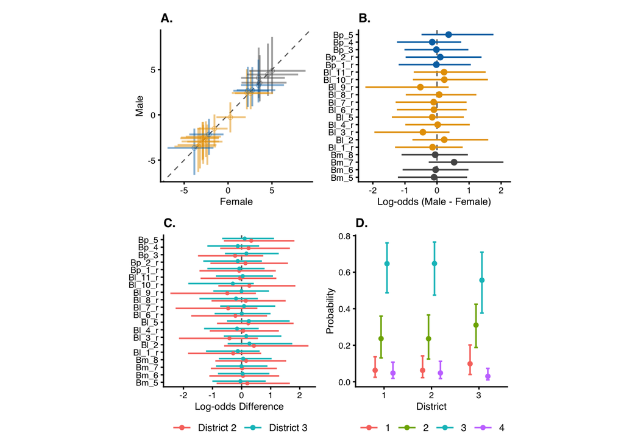

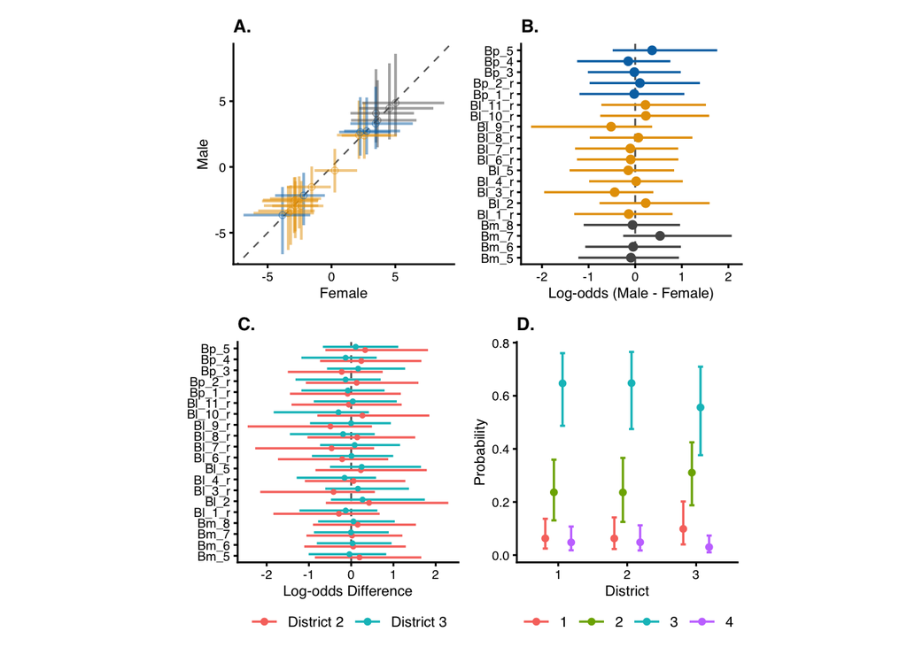

```r
fig_7
```